# Support for QIIME in R

## Why use R

First published in 1996, [“R”](http://www.R-project.org) is an integrated software application and programming language designed for interactive data analysis (R Core Team). It is available for Linux, Mac OS, and Windows free of charge under an open-source license [GPL2](http://www.gnu.org/licenses/gpl-2.0.html). Since its inception R has had an emphasis on being a tool for interactive statistical analysis through [functional programming](http://en.wikipedia.org/wiki/Functional_programming), where the primary investigative and inferrential activites are performed by writing a series of repeatable commands into “scripts” that can be recorded and published. This paradigm lends itself well to reproducible research, and is enhanced substantially by R's integration with tools for literate programming such as [Sweave](http://www.stat.uni-muenchen.de/%7Eleisch/Sweave/) ( Leisch 2002), [knitr](http://cran.r-project.org/web/packages/knitr/citation.html) (Xie 2013), and R [markdown](http://cran.r-project.org/web/packages/markdown/index.html) (Allaire 2013), as well as data graphics. There are thousands of free and open-source extensions to R (“packages”) available from the main R repository, [CRAN](http://cran.r-project.org/), further organized by volunteer experts into 31 [task views](http://cran.r-project.org/web/views/). Among these are dedicated package views relevant to microbiome data, including [phylogenetics](http://cran.r-project.org/web/views/Phylogenetics.html), [clustering](http://cran.r-project.org/web/views/Cluster.html), [environmetrics](http://cran.r-project.org/web/views/Environmetrics.html), [machine learning](http://cran.r-project.org/web/views/MachineLearning.html), [multivariate](http://cran.r-project.org/web/views/Multivariate.html) and [spatial statistics](http://cran.r-project.org/web/views/Spatial.html), as well as a separate reviewed and curated repository dedicated to biological statistics called [Bioconductor](http://bioconductor.org/) (over 600 packages).

## Examples

As with some of the earlier examples of QIIME commands with corresponding output and figures, in this section we have included some key R commands potentially useful during interactive analysis in the R environment. For simplicity we are only showing results related to the open-reference OTU data, stored in an object in our examples named `open`, and imported into R using the phyloseq command `import_biom`.

```r
open = import_biom("path-to-file.biom", ...)
```

Although not always very illuminating, a comparison of OTU-richness between samples or groups of samples can easily be achieved with the `plot_richness` command. For the most precise estimates of richness for most samples, this should be performed *before* random subsampling or other transformations of the abundance data. Here `open` contains data that has already been randomly subsampled. In the following graphic we can see that the wild type samples are generally more diverse (higher richness) and somewhat more variable than the transgenic samples for essentially all body sites, though the differences between the two mice genotypes are small.

```r
plot_richness(open, x = "BODY_SITE", color = "GENOTYPE") + geom_boxplot()
```

This plot command also illustrates the use of a function in ggplot2, `geom_boxplot`, that instructs the ggplot2 graphics engine to add an additional graphical element – in this case a boxplot for each of the natural groups in the graphic. These available additional graphical instructions (called “layers” in the grammar of graphics nomenclature) are embedded with the returned plot object for subsequent rendering, inspection, or further modification, allowing for powerfully customized representations of the data.

In this first version fo the figure, a base graphic is created in which the bars are color-filled according to phyla, with each rectangle representing the relative abundance of a phylum in a particular sample group and then stacked from largest to smallest. The `facet_grid(~GENOTYPE)` layer then separates the data into two equivalent panels, one for each genotype in the data.

```r
p2 = plot_bar(openphyab, "bodysite", fill = "phyla", title = title)
p2 + facet_grid(~GENOTYPE)
```

From this first bar plot it is clear that all body sites from the average wildtype mouse have Firmicutes as their phylum of largest cumulative proportion, except for the “feces”, where it is anyway a close call between firmicutes and bacteroidetes. By contrast, some of the average transgenic mice samples have a much higher proportion of proteobacteria or bacteroidetes than the corresponding wild type samples. One draw back of this kind of stacked bar representation is that it is difficult to compare any of the sub-bars except for those at the bottom. This can be easily alleviated by changing the `facet_grid` call such that a separate panel is made for each phyla in the dataset, as follows.

```r
p2 + facet_grid(phyla ~ GENOTYPE) + ylim(0, 100)
```

With essentially the same effort to produce, the 14 panels of this second bar plot graphic allow an easy and quantitative comparison of the relative abundances of each phyla across body sites and genotype.

#### Ordination methods.

Microbiome datasets can be quite multivariate in nature, and dimensional reduction ([ordination](http://en.wikipedia.org/wiki/Ordination)) methods can be a useful form of exploratory analysis to better understand some of the largest patterns in the data. Many ordination methods are wrapped in phyloseq by the `ordinate` function, and many more are offered in available R packages. Here is an example performing multidimensional scaling (MDS) on the precomputed unweighted UniFrac distance matrix for the open-reference dataset. The ordination result (`openUUFMDS`) is first passed to `plot_scree` in order to explore the “scree plot” representing the relative proportions of variability represented by each successive axis. Both the ordination result and the original data are then passed to `plot_ordination` with sufficent parameters to shade the sample points by genotype, and create separate panels for each body site.

```r
openUUFMDS = ordinate(open, "MDS", distance = UniFrac[["unweighted"]][["open"]])
plot_scree(openUUFMDS, "Eignevalues for unweighted UniFrac MDS")
plot_ordination(open, openUUFMDS, color = "GENOTYPE") + geom_point(size = 5) +
    facet_wrap(~BODY_SITE)
```

#### Heatmaps

Heatmaps can be useful for exploratory analysis of microbiomes by mapping abundance values to a color scale in a condensed, pattern-rich format. A good heatmap graphic will often generate hyotheses about sample and/or OTU clustering in the data that must then be more fully vetted. There are two structural aspects of a heatmap graphic that control whether or not it will reveal any interpretable patterns: (1) the ordering of axes, and (2) the color scaling. For example, the `plot_heatmap()` command in the phyloseq package takes a similar approach to NeatMap (Rajaram and Oono, PMID 20096121), in that it uses ordination results rather than hierarchical clustering to determine the index order for each axis. For `plot_heatmap`, the default color scaling maps a particular shade of blue to a log transformation of abundance that works well for microbiome data, although this transformation is also user-definable.

```r
title = "plot_heatmap using NMDS/Bray-Curtis for both axes ordering"
plot_heatmap(openfpp, "NMDS", "bray", taxa.label = "Phylum", sample.label = "bsgt",
    title = title)
```

## Begin Evaluated Code Examples

This document serves as a reproducible, supplementary tutorial for importing the example data and performing some example analyses in R using phyloseq.

The following includes some examples importing QIIME data and creating data graphics. Some preprocessing steps are omitted because they were performed prior to import using tools in QIIME.

Use the `import_biom` function in phyloseq to import `.biom` and associated files from each dataset type into R, represented as a single integrated object. First we have to load the phyloseq extension/library/package (these terms are roughly equivalent in R).

Load required packages for import, show package version.

```r
library("phyloseq")
packageVersion("phyloseq")
```

```
## [1] '1.5.20'
```

### Define files

Find the data files that we want to import. Uses some regular expression matching recursively in the directory we're in.

```r
biomfiles = list.files(getwd(), "\\.biom$", recursive = TRUE)
names(biomfiles) <- c("closed", "denovo", "open")
# Find the phylogenetic tree files.
treefiles = list.files(getwd(), "\\.tre[e]{0,}$", recursive = TRUE)
names(treefiles) <- c("denovo", "closed", "open")
# Find the DNA sequence (`.fasta`) file(s) with the representative
# sequences for each OTU.  Only available for 'closed'
rsfiles = list.files(getwd(), "\\.fasta$", recursive = TRUE)
names(rsfiles) <- c("closed")
# Find and import the 'mapping file' with sample covariate data.  There's
# only one.
mapfiles = list.files(getwd(), "\\_map\\.txt$", recursive = TRUE)
sada = import_qiime_sample_data(mapfiles)
```

### Import data

In this case, we show as an example importing the open-reference files.

```r
openrefRfile = "imported-open-ref.RData"
```

If the files have not already been imported and saved yet then do that. If the result file is already present in compressed `.RData` format, then this import part is skipped. To re-run, you can simply delete the file, imported-open-ref.RData.

```r
if (!file.exists(openrefRfile)) {
    open = import_biom(biomfiles["open"], treefiles["open"], parseFunction = parse_taxonomy_greengenes)
    # Add sample map data to the open-reference data object called `open`.
    open = merge_phyloseq(open, sada)
    # Remove any samples that don't have a body site `NA`.
    open = subset_samples(open, !is.na(BODY_SITE))
    # Save to openrefRfile
    save(open, file = openrefRfile)
} else {
    load(openrefRfile)
}
```

### Import closed-reference or de novo files

One could repeat the process above to import the files for closed-reference and de novo OTU clustering, already identified in the file name vectors above. However, these comparisons are already described in other parts of the article to which this is a supplement, and do not need to be repeated here.

### Import pre-calculated UniFrac distance matrices

```r
UUFfiles = list.files(getwd(), "^unweighted\\_unifrac\\_dm\\.txt$", recursive = TRUE)
WUFfiles = list.files(getwd(), "^weighted\\_unifrac\\_dm\\.txt$", recursive = TRUE)
names(UUFfiles) <- c("closed", "denovo", "open")
names(WUFfiles) <- c("closed", "denovo", "open")
# Read each distance matrix as a data.frame, store in a list
UUFL = lapply(UUFfiles, read.table, header = TRUE)
WUFL = lapply(WUFfiles, read.table, header = TRUE)
# Re-order the open-reference distances to match data object `open`
reorderdists = function(distdf, newI) {
    distdf <- distdf[newI, ]
    distdf <- distdf[, newI]
    return(distdf)
}
UUFL = lapply(UUFL, reorderdists, newI = sample_names(open))
WUFL = lapply(WUFL, reorderdists, newI = sample_names(open))
# Coerce each data.frame to a 'dist' object
UUFL = lapply(UUFL, as.dist)
WUFL = lapply(WUFL, as.dist)
# Combine into a bigger nested list
UniFrac = list(unweighted = UUFL, weighted = WUFL)
```

### load ggplot2 and do themes

Load the ggplot2 package for full access of its graphics tools and customizations. Then set some custom default plot parameters for graphics theme and discrete color scale.

```r
library("ggplot2")
theme_set(theme_bw())
scale_colour_discrete <- function(...) {
    scale_colour_brewer(palette = "Set1", ...)
}
scale_fill_discrete <- function(...) {
    scale_fill_brewer(palette = "Set1", ...)
}
```

### Richness estimates

Create a summary of richness estimates, attempting different combinations of variable organization. Simply plotting all of the samples, even with labels, would not be very illuminating. Here we try a few different choices for organization, and find that it looks like the microbiomes associated with the WT genotype have a richness that is more variable and possibly more diverse (larger).

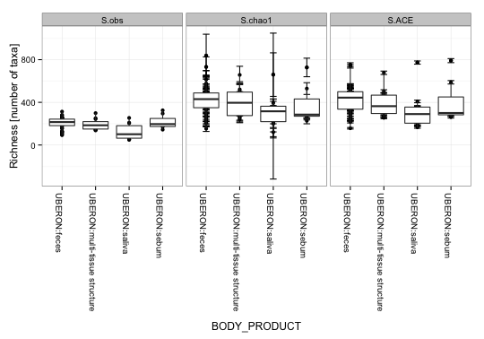

```r
# Remove the 'UBERON:' label from each BODY_SITE entry
sample_data(open)$BODY_SITE <- gsub("^UBERON\\:", "", get_variable(open, "BODY_SITE"))
plot_richness(open, x = "BODY_PRODUCT") + geom_boxplot()
```

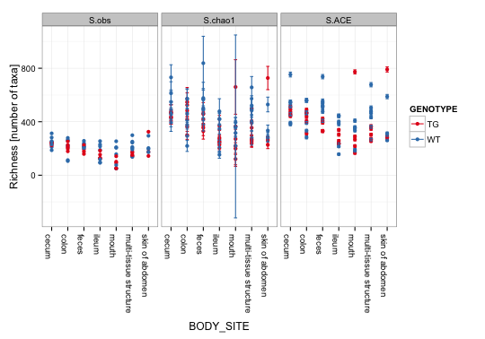

```r
prich = plot_richness(open, x = "BODY_SITE", color = "GENOTYPE")
prich
```

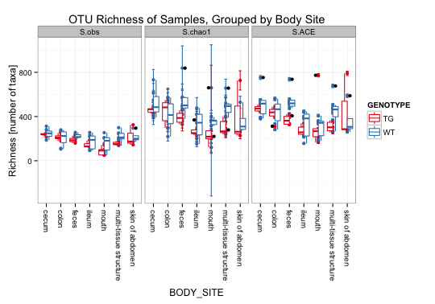

```r
# Additional ggplot2 adjustments for publication
prich = prich + geom_boxplot()
prich = prich + theme(text = element_text(size = 12), axis.text.x = element_text(vjust = 0.5))
prich = prich + ggtitle("OTU Richness of Samples, Grouped by Body Site")
prich
```

```r
# Command to save the figure as PDF, then JPG
dev.off()
```

```r
ggsave("Figure_22.pdf", prich, width = 7.5, height = 5.25)
ggsave("Figure_22.jpg", prich, width = 7.5, height = 5.25, dpi = 300)
```

### Flexible plots of abundances

I want to make a plot of relative abundance by `BODY_SITE`, but I also want to be able to show the effect of `GENOTYPE`, being informed by some earlier exploratory analysis which is show later. The first thing to do is to add a dummy variable for merging that combines the two categorical variables I want to compare.

```r
# Make a new lower-case bodysite label with 'UBERON:' removed
sample_data(open)$bodysite <- gsub("^UBERON\\:", "", get_variable(open, "BODY_SITE"))
# change 'multi-tissue structure' to just multi-tissue
sample_data(open)$bodysite <- factor(gsub(" structure$", "", get_variable(open,
    "bodysite")))
# Merge based on the dummy variable, bsgt
sample_data(open)$bsgt <- paste0(get_variable(open, "bodysite"), get_variable(open,
    "GENOTYPE"))
sample_data(open)$bsgt <- factor(sample_data(open)$bsgt)
openbsgtmerge = merge_samples(open, "bsgt")
```

Repair R factors that were damaged (coerced to integers) during standard merge.

```r
# repair factors
sample_data(openbsgtmerge)$bodysite <- levels(sample_data(open)$bodysite)[get_variable(openbsgtmerge,
    "bodysite")]
sample_data(openbsgtmerge)$GENOTYPE <- levels(sample_data(open)$GENOTYPE)[get_variable(openbsgtmerge,
    "GENOTYPE")]
# transform merged data to proportions out of 100 (percent)
openbsgtmerge = transform_sample_counts(openbsgtmerge, function(x) 100 * x/sum(x))
```

Define a special set of Phyla that we want to focus on in our plotting. We have prior knowledge that these are important, and that we might want to lump the other phyla into an “other” category.

```r
plotphyla = c("Proteobacteria", "Fusobacteria", "Firmicutes", "Deferribacteres",
    "Cyanobacteria", "Bacteroidetes", "Actinobacteria")
tax_table(openbsgtmerge) <- cbind(phyla = NA_character_, tax_table(openbsgtmerge))
wh1 = which(tax_table(openbsgtmerge)[, "Phylum"] %in% plotphyla)
tax_table(openbsgtmerge)[wh1, "phyla"] <- tax_table(openbsgtmerge)[wh1, "Phylum"]
```

Now use `plot_bar` to show the relative abundances. We can show with and without separate by `GENOTYPE`.

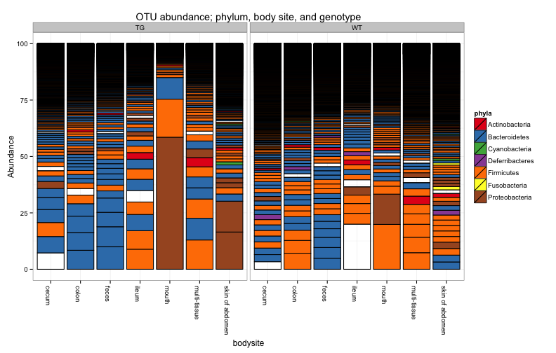

```r
title = "OTU abundance; phylum, body site, and genotype"
p1 = plot_bar(openbsgtmerge, "bodysite", fill = "phyla", title = title)
p1 + facet_grid(~GENOTYPE)
```

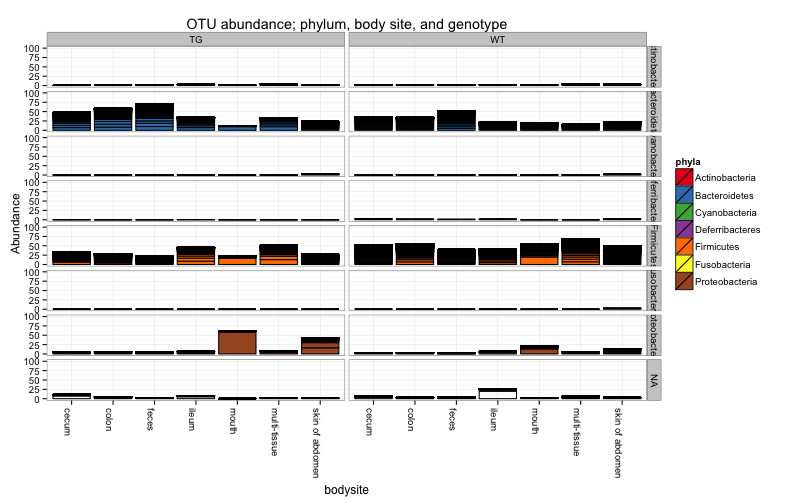

```r
p1 + facet_grid(phyla ~ GENOTYPE) + ylim(0, 100)
```

Now the same style of plot, but after removing the unknown (NA) OTUs, and agglomerating the OTUs from the same phylum. Figure 23.

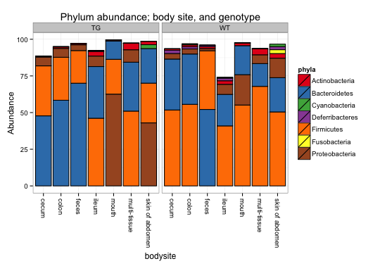

```r
title = "Phylum abundance; body site, and genotype"
openphyab = openbsgtmerge
tax_table(openphyab) <- tax_table(openphyab)[, c("Kingdom", "phyla")]
openphyab = tax_glom(openphyab, "phyla")
p2 = plot_bar(openphyab, "bodysite", fill = "phyla", title = title)
p2 = p2 + theme(text = element_text(size = 12), axis.text.x = element_text(vjust = 0.5))
# Figure 23
fig23 = p2 + facet_grid(~GENOTYPE)
fig23
```

```r
dev.off()
```

```r
ggsave("Figure_23.pdf", fig23, width = 7.5, height = 5.25)
ggsave("Figure_23.jpg", fig23, width = 7.5, height = 5.25, dpi = 300)
```

Figure 24 - faceting. Created by adding layers to previous figure, `p2`.

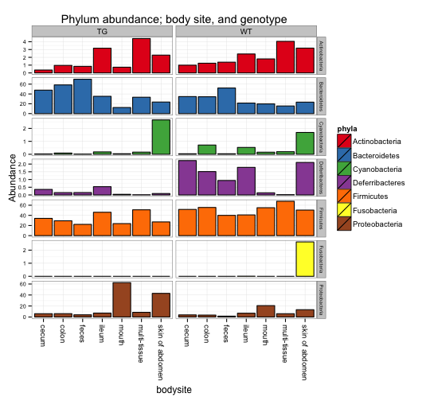

```r
fig24 = p2 + facet_grid(phyla ~ GENOTYPE, scales = "free_y")
fig24 = fig24 + theme(axis.text.y = element_text(size = 7), strip.text.y = element_text(size = 6))
fig24
```

```r
dev.off()
```

```r
ggsave("Figure_24.pdf", fig24, width = 7.5, height = 7)
ggsave("Figure_24.jpg", fig24, width = 7.5, height = 7, dpi = 300)
```

Can also try to visualize on a phylogenetic tree, since we have one integrated with this data (including all the transformations, filtering we've been doing)

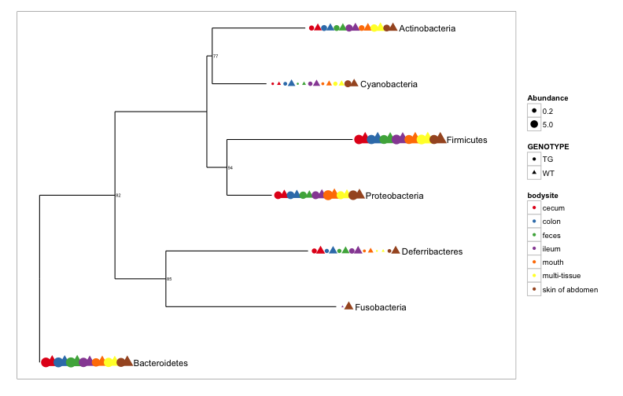

```r
plot_tree(openphyab, nodelabf = nodeplotboot(), color = "bodysite", label.tips = "phyla",
    shape = "GENOTYPE", size = "abundance", ladderize = "left", plot.margin = 0.45)
```

### MDS/PCoA on weighted and unweighted UniFrac distances

In phyloseq, many native dimensional reduction ([ordination](http://en.wikipedia.org/wiki/Ordination)) methods are wrapped by the `ordinate` function, which calculates and returns different ordination results classes, depending on the `method` chosen for ordination (see `help("ordinate")` for more details).

Here we can visually compare the MDS ordinations on weighted and unweighted UniFrac distances.

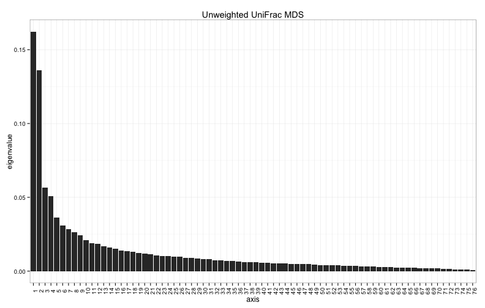

```r
openUUFMDS = ordinate(open, "MDS", distance = UniFrac[["unweighted"]][["open"]])
openWUFMDS = ordinate(open, "MDS", distance = UniFrac[["weighted"]][["open"]])
plot_scree(openUUFMDS, "Unweighted UniFrac MDS")
```

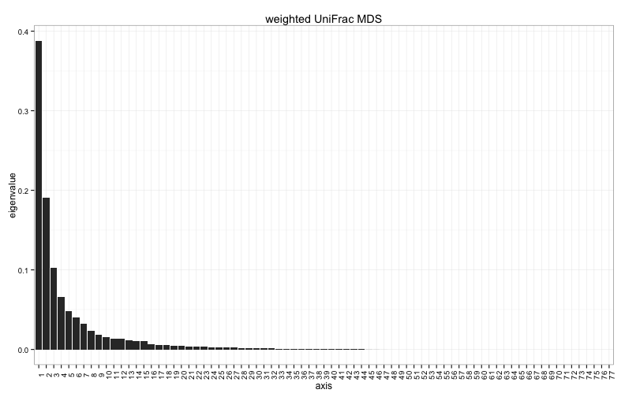

```r
plot_scree(openWUFMDS, "weighted UniFrac MDS")
```

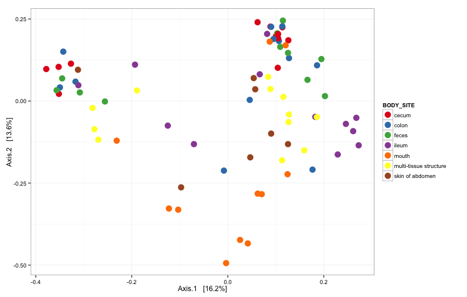

```r
plot_ordination(open, openUUFMDS, color = "BODY_SITE") + geom_point(size = 5)
```

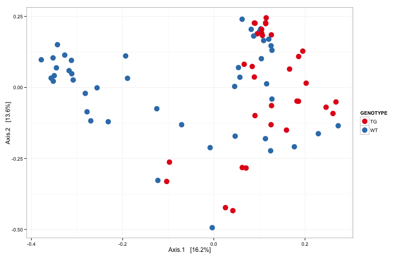

```r
pu = plot_ordination(open, openUUFMDS, color = "GENOTYPE") + geom_point(size = 5)
pu
```

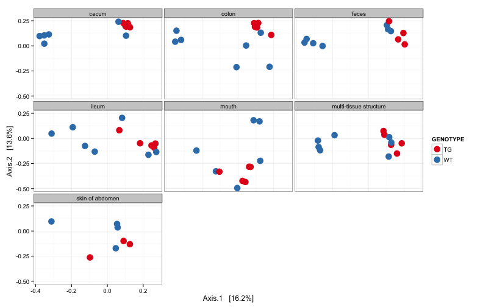

```r
pu + facet_wrap(~BODY_SITE)
```

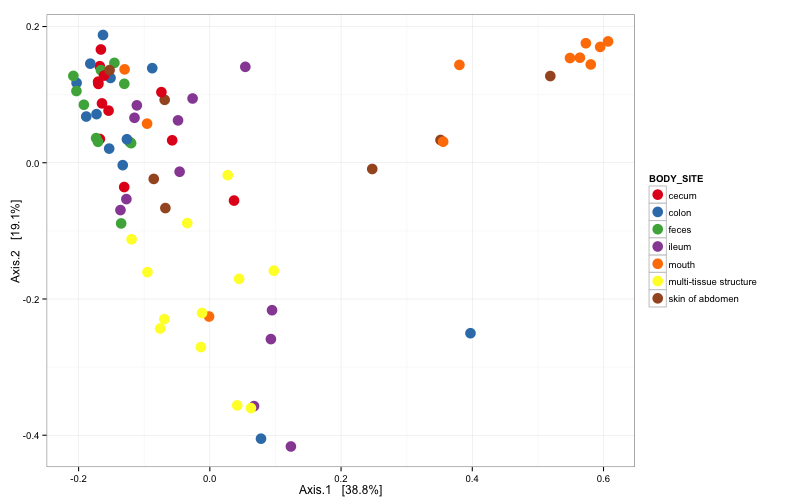

```r
plot_ordination(open, openWUFMDS, color = "BODY_SITE") + geom_point(size = 5)
```

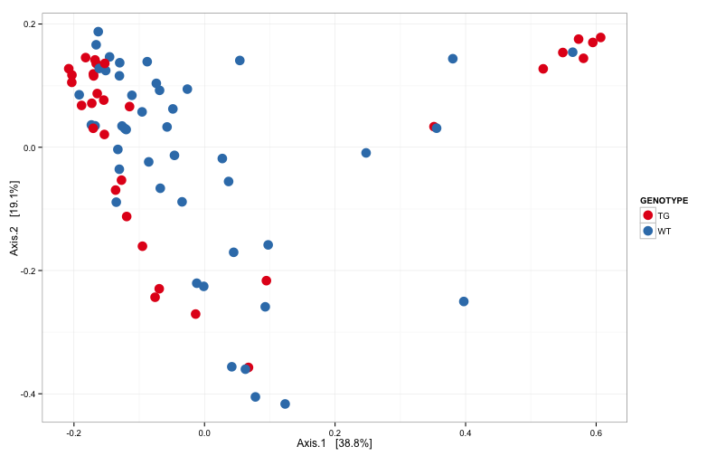

```r
pw = plot_ordination(open, openWUFMDS, color = "GENOTYPE") + geom_point(size = 5)
pw
```

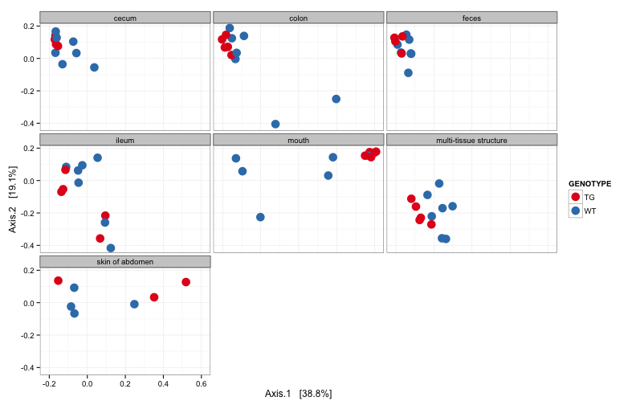

```r
pw + facet_wrap(~BODY_SITE)
```

Grab the left-hand subset of data, label cluster.

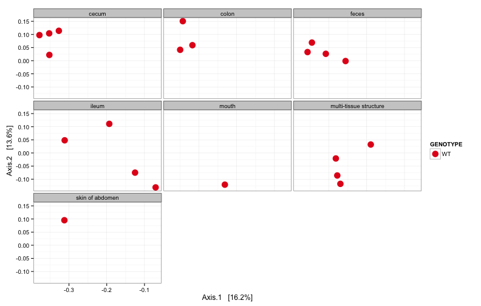

```r
pus = pu
pus$data <- pu$data[which(pu$data$Axis.1 < -0.05 & pu$data$Axis.2 > -0.25),
    ]
pus + facet_wrap(~BODY_SITE)
```

```r
# Add 'cluster' label to sample data
sample_data(open)$cluster <- "right"
sample_data(open)[rownames(pus$data), "cluster"] <- "left"
```

Testing taxa abundance correlation between binary groups using permutation t-test and multiple hypothesis correction, `mt`. For speed and power, we first apply a filter in which OTUs are removed that do not change much across samples, standard deviation less than 5 (arbitrary, not rigorously chosen threshold).

```r
# hist(apply(otu_table(open), 1, sd), breaks=500, xlim=c(10, 200),
# ylim=c(0, 50))
testOTUs = names(which(apply(otu_table(open), 1, sd) > 5))
openfilt = prune_taxa(testOTUs, open)
opmt = mt(openfilt, "cluster")
```

[output not shown]

```r
opmt[opmt$adjp < 0.01, c("adjp", "Phylum", "Class", "Genus")]
```

```
##                       adjp         Phylum                 Class
## 308076              0.0028  Bacteroidetes           Bacteroidia
## 431900              0.0028  Bacteroidetes           Bacteroidia
## 212201              0.0028  Bacteroidetes           Bacteroidia
## 199118              0.0028  Bacteroidetes           Bacteroidia
## 272850              0.0028  Bacteroidetes           Bacteroidia
## 355746              0.0028  Bacteroidetes           Bacteroidia
## 261177              0.0028  Bacteroidetes           Bacteroidia
## New.ReferenceOTU182 0.0028           <NA>                  <NA>
## 374370              0.0028  Bacteroidetes           Bacteroidia
## 277624              0.0028  Bacteroidetes           Bacteroidia
## 398839              0.0028 Proteobacteria    Betaproteobacteria
## New.ReferenceOTU61  0.0028  Bacteroidetes           Bacteroidia
## 262938              0.0028     Firmicutes       Erysipelotrichi
## 181719              0.0028  Bacteroidetes           Bacteroidia
```

[output cut: 75 more lines]

Permanova / adonis

```r
library("vegan")
adonis(UniFrac$unweighted$open ~ cluster + GENOTYPE + BODY_SITE, as(sample_data(open),
    "data.frame"))
```

```
##
## Call:
## adonis(formula = UniFrac$unweighted$open ~ cluster + GENOTYPE +      BODY_SITE, data = as(sample_data(open), "data.frame"))
##
## Terms added sequentially (first to last)
##
##           Df SumsOfSqs MeanSqs F.Model    R2 Pr(>F)
## cluster    1      2.41   2.405   13.85 0.139  0.001 ***
## GENOTYPE   1      0.22   0.215    1.24 0.012  0.153
## BODY_SITE  6      2.85   0.475    2.74 0.165  0.001 ***
## Residuals 68     11.81   0.174         0.683
## Total     76     17.28                 1.000
## ---
## Signif. codes:  0 '***' 0.001 '**' 0.01 '*' 0.05 '.' 0.1 ' ' 1
```

Mantel test

```r
mantel(UniFrac$unweighted$open, UniFrac$weighted$open)
```

```
##
## Mantel statistic based on Pearson's product-moment correlation
##
## Call:
## mantel(xdis = UniFrac$unweighted$open, ydis = UniFrac$weighted$open)
##
## Mantel statistic r: 0.688
##       Significance: 0.001
##
## Upper quantiles of permutations (null model):
##    90%    95%  97.5%    99%
## 0.0751 0.1032 0.1250 0.1496
##
## Based on 999 permutations
```

### Heatmap

The `plot_heatmap` function in phyloseq can create heatmaps that are very useful for exploratory analysis, leading you to hypotheses that you can then more fully vet. For more details and examples, see [the plot_heatmap tutorial](http://joey711.github.io/phyloseq/plot_heatmap-examples). Briefly, there are two extremely important aspects of a heatmap graphic that can often dictate whether or not it reveals any interpretable patterns: (1) the ordering of axes, and (2) the color scaling. Addressing item 1, the `plot_heatmap` function in phyloseq takes a similar approach to [the NeatMap package](http://cran.r-project.org/web/packages/NeatMap/index.html), in that it uses ordination results rather than hierarchical clustering to determine the axis orders. Addressing item 2, the color scaling maps color shading to a particular log transformation of abundance that seems to work well for microbiome data, and is also completely user-definable with all manner of alternative scalings supported by [the scales package](http://cran.r-project.org/web/packages/scales/index.html), including linear and identity transformations. However, we find that some manner of log transformation is usually best.

To make an interpretable heatmap, we need to do some filtering of OTUs that just don't appear in very many samples and make the graphic look dark and empty. They are not contributing much to our understanding of the samples, so why should we include them in the graphic? Here is what I mean (for fairness, using the `plot_heatmap` function and MDS/UniFrac as the ordination method):

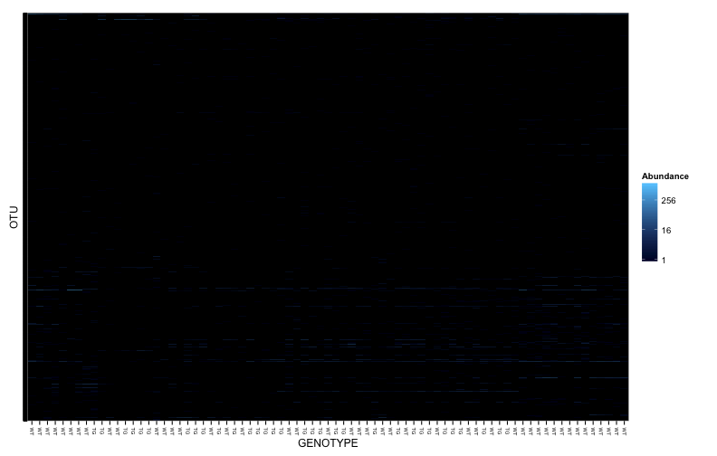

```r
plot_heatmap(open, "MDS", UniFrac$unweighted$open, sample.label = "GENOTYPE")
```

By default `plot_heatmap` omits the labels of axes with a large number of features. Even on a screen with fairly high resolution it is difficult to discern any but a few of the most abundant and prevalent OTUs in the previous graphic.

Let's instead trim OTUs that do not appear in very many samples in the dataset. We'll sort first by prevalance (defined here as number of samples appeared) and then by abundance value. This new filtered version of the dataset is called `openfp`.

We need to decide how many OTUs to include, and this should be based on the data in some way. For example here, I've plotted the prevalence of OTUs to help justify/indicate why 100 OTUs was chosen. It is an arbitrary value on its own, but conservative when considering the number of samples in which OTUs appear (see plot below). In a sorted order by prevalence, the 100th OTU is already appearing in less than 26% of samples. Adding more OTUs is adding sparsity to a graphic in which sparsity makes patterns more difficult to see. The following is the code that filters these 100 “most prevalent” OTUs, and stores this filtered data as `openfp`.

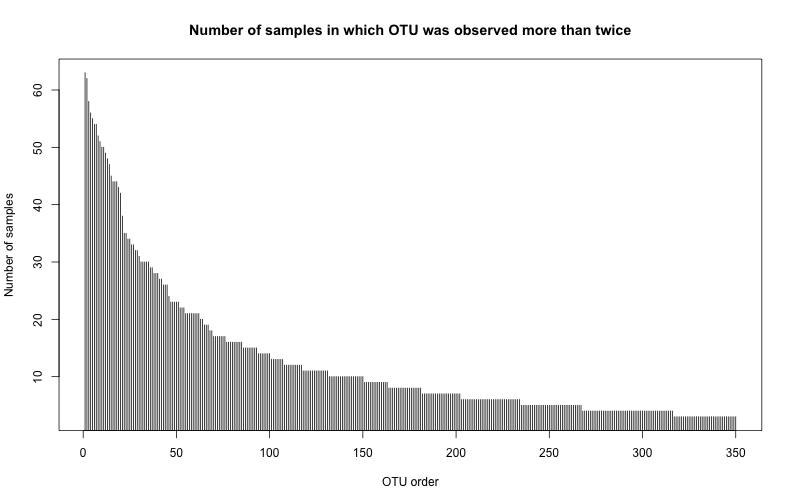

```r
samobs = apply(otu_table(open), 1, function(x, m) sum(x > m), m = 2)
main = "Number of samples in which OTU was observed more than twice"
plot(sort(samobs, TRUE)[1:350], type = "h", main = main, ylab = "Number of samples",
    xlab = "OTU order")
```

```r
otudf = data.frame(prev = samobs, sums = taxa_sums(open))
otudf = otudf[order(-otudf$prev, -otudf$sums), ]
openfp = prune_taxa(rownames(otudf)[1:100], open)
```

Count and show total reads for each phylum…

```r
tapply(taxa_sums(openfp), factor(tax_table(openfp)[, "Phylum"]), sum)
```

```
##  Actinobacteria   Bacteroidetes   Cyanobacteria Deferribacteres
##            1799           30846             221             867
##      Firmicutes  Proteobacteria     Tenericutes             TM7
##           30766           10940             198             118
```

```r
get_taxa_unique(openfp, "Phylum")
```

```
## [1] "Bacteroidetes"   "Proteobacteria"  "Firmicutes"      "Cyanobacteria"
## [5] NA                "Tenericutes"     "Actinobacteria"  "TM7"
## [9] "Deferribacteres"
```

Looks like most of the remaining reads/OTUs in this dataset are Bacteroidetes, Firmicutes, Proteobacteria, and Actinobacteria. Subset to those. Also, change the combined label from `bsgt` to `body site and genotype`.

```r
keepPhy = c("Bacteroidetes", "Firmicutes", "Proteobacteria", "Actinobacteria")
openfpp = subset_taxa(openfp, Phylum %in% keepPhy)
openfpp
```

```
## phyloseq-class experiment-level object
## otu_table()   OTU Table:         [ 93 taxa and 77 samples ]
## sample_data() Sample Data:       [ 77 samples by 56 sample variables ]
## tax_table()   Taxonomy Table:    [ 93 taxa by 8 taxonomic ranks ]
## phy_tree()    Phylogenetic Tree: [ 93 tips and 92 internal nodes ]
```

Yep. Only lost 7 OTUs.

#### plot_heatmap

Now let's use this filtered data to create a more interpretable heatmap, still using `plot_heatmap` in phyloseq.

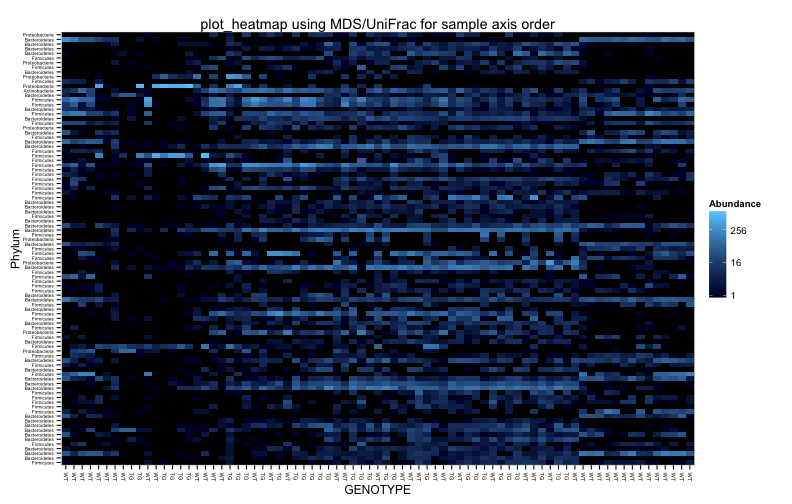

```r
title = "plot_heatmap using MDS/UniFrac for sample axis order"
plot_heatmap(openfpp, "MDS", UniFrac$unweighted$open, taxa.label = "Phylum",
    sample.label = "GENOTYPE", title = title)
```

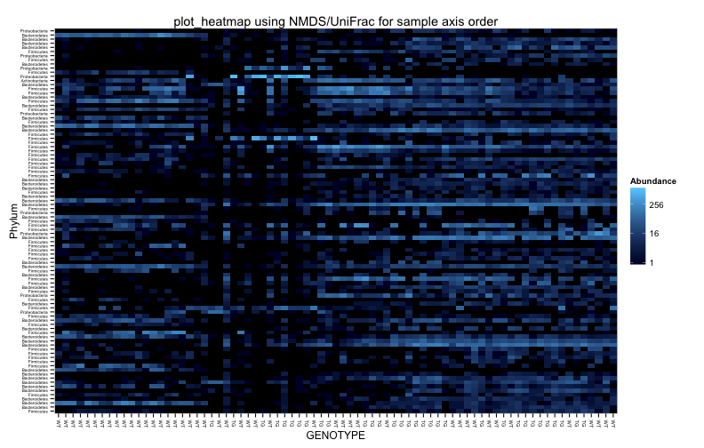

```r
title = "plot_heatmap using NMDS/UniFrac for sample axis order"
plot_heatmap(openfpp, "NMDS", UniFrac$unweighted$open, taxa.label = "Phylum",
    sample.label = "GENOTYPE", title = title)
```

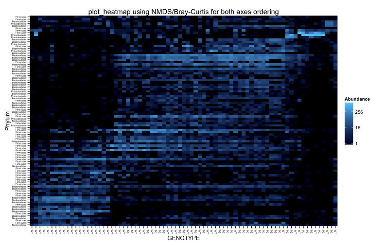

```r
title = "plot_heatmap using NMDS/Bray-Curtis for both axes ordering"
p3 = plot_heatmap(openfpp, "NMDS", "bray", taxa.label = "Phylum", sample.label = "GENOTYPE",
    title = title)
p3
```

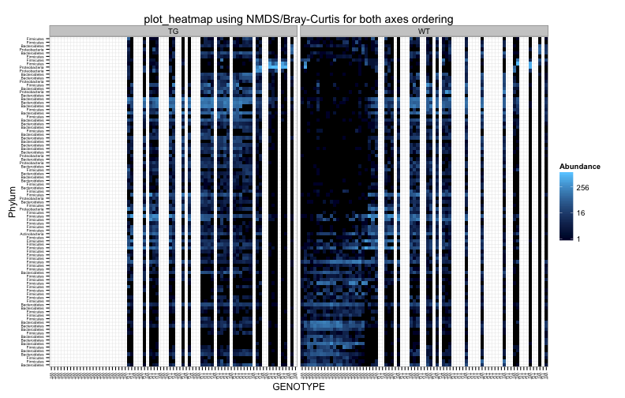

```r
p3 + facet_grid(~GENOTYPE)
```

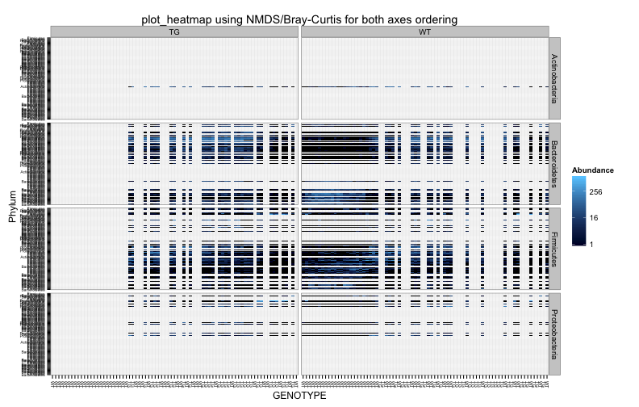

```r
p3 + facet_grid(Phylum ~ GENOTYPE)
```

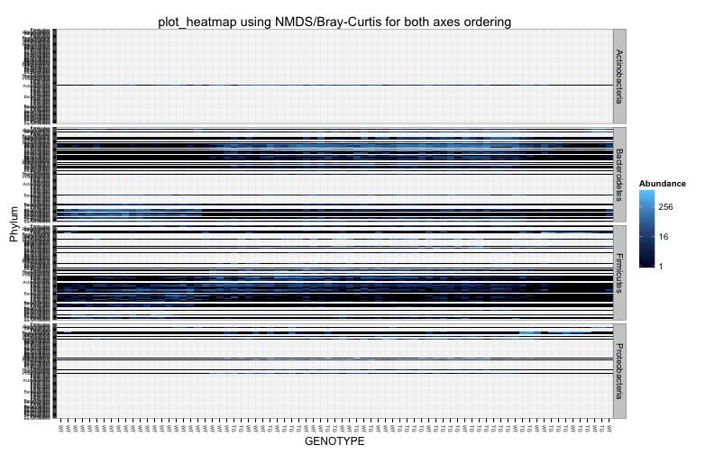

```r
p3 + facet_grid(Phylum ~ .)
```

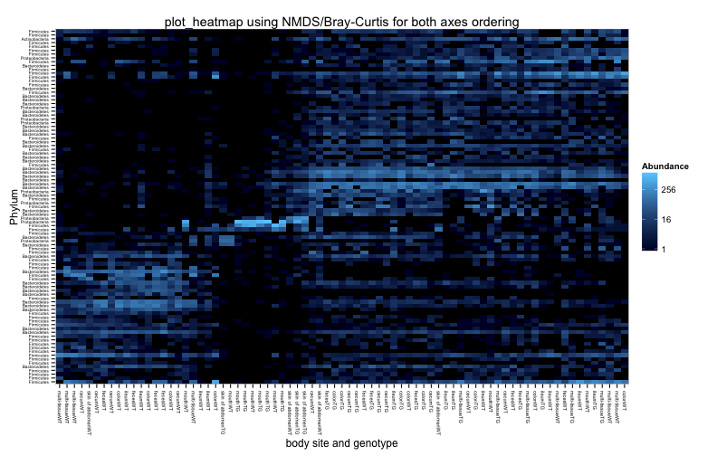

```r
xlab = "body site and genotype"
title = "plot_heatmap using NMDS/Bray-Curtis for both axes ordering"
p4 = plot_heatmap(openfpp, "NMDS", "bray", taxa.label = "Phylum", sample.label = "bsgt",
    title = title)
p4$scales$scales[[1]]$name <- xlab
p4
```

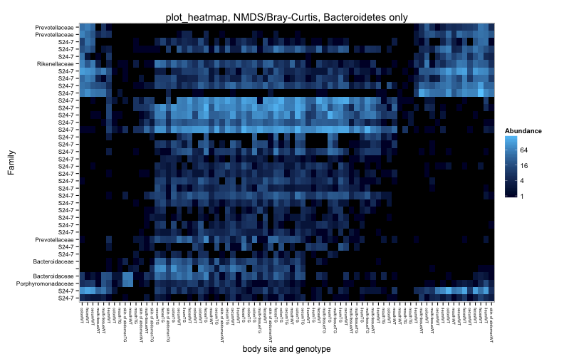

```r
openfpp.bac = subset_taxa(openfpp, Phylum == "Bacteroidetes")
title = "plot_heatmap, NMDS/Bray-Curtis, Bacteroidetes only"
p4 = plot_heatmap(openfpp.bac, "NMDS", "bray", taxa.label = "Family", sample.label = "bsgt",
    title = title)
p4$scales$scales[[1]]$name <- xlab
p4
```